# Non-identical Bernoulli (basketball shots)

Part of my CLT stress test. Every shot has its own chance of going in.

Author

Geonho Lee

Published

October 11, 2026

```r
source("clt_helpers.R")

student_id <- 5146
cutoff <- 0.3
```

## 1 The population

This is the fatigue example from the class handout. A player’s first shot goes in 90% of the time, and by the last shot it is down to 50%, dropping in a straight line in between. Each shot is a 1 (make) or a 0 (miss), so the sample mean is just the shooting percentage for the game.

The handout uses 20 shots. To try different n, I keep the same idea for any number of shots: the first shot is always 0.90, the last is always 0.50, and the rest are evenly spaced in between. So for every n the average probability is exactly 0.70.

The shots are independent and each one has a finite variance, but they are not identically distributed, so one of the three CLT assumptions is broken. The handout says a normal approximation can still work “under additional conditions,” so this is a test of whether that happens here.

```r
shot_probs <- function(n) seq(0.90, 0.50, length.out = n)

p20 <- shot_probs(20)
round(c(average_p = mean(p20), first = p20[1], last = p20[20]), 3)
```

```
average_p     first      last
      0.7       0.9       0.5
```

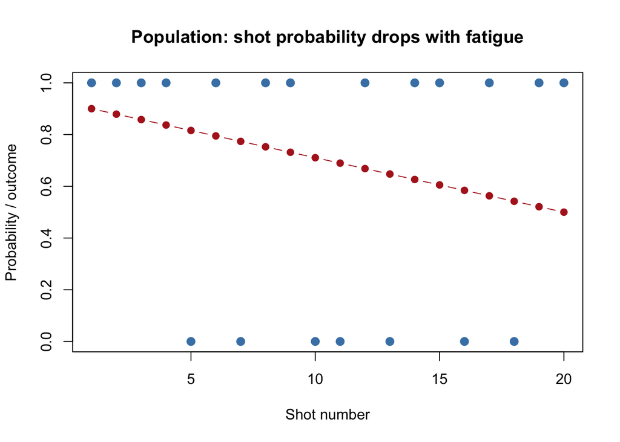

Red = chance of making each shot in a 20-shot game. Blue = one simulated game.

```r
set.seed(student_id)
one_game <- rbinom(20, size = 1, prob = p20)

plot(1:20, p20, type = "b", pch = 19, ylim = c(0, 1), col = "firebrick",
     xlab = "Shot number", ylab = "Probability / outcome",
     main = "Population: shot probability drops with fatigue")
points(1:20, one_game, pch = 19, col = "steelblue", cex = 1.2)
```

There is not one population sd here, since every shot has its own. A 90% shot has sd sqrt(0.9 × 0.1) = 0.30, and a 50% shot has sd 0.50.

## 2 What I expected before running anything

If every shot were 70%, this would just be a Bernoulli(0.7) and I could use the same formulas as the other files:

```r
p_bar <- 0.7
skew_70 <- (1 - 2 * p_bar) / sqrt(p_bar * (1 - p_bar))
exkurt_70 <- (1 - 6 * p_bar * (1 - p_bar)) / (p_bar * (1 - p_bar))

c(n_for_skew = (skew_70 / cutoff)^2, n_for_kurt = abs(exkurt_70) / cutoff)
```

```
n_for_skew n_for_kurt
  8.465608   4.126984
```

That says about 8.5, so 9. But the shots are not identical, so it is not obvious that number still applies. It is also not clear the usual standard error σ/√n is still right, because there is no single σ.

## 3 Simulation

For each n I simulate 10,000 games of n shots and keep the shooting percentage of each one. Same 51 values of n as the exponential file. I also run a constant 70% shooter with the same seed so I can compare the two directly.

```r
sim <- run_simulation(
  generator = function(n) rbinom(n, size = 1, prob = shot_probs(n)),
  pop_sd = sqrt(0.7 * 0.3),   # the usual formula, pretending every shot is 70%
  seed = student_id
)
results <- sim$results

constant <- run_simulation(
  generator = function(n) rbinom(n, size = 1, prob = 0.7),
  pop_sd = sqrt(0.7 * 0.3),
  seed = student_id
)$results
```

## 4 The standard error

Since every shot has its own p, the variance of the total is the sum of each shot’s variance, p(1 - p). Dividing by n gives the SE of the shooting percentage:

```r
exact_se <- function(n) {
  p <- shot_probs(n)
  sqrt(sum(p * (1 - p))) / n
}

results_exact <- results
results_exact$theory_se <- sapply(results$n, exact_se)
results_exact$sd_error <- abs(results$sd - results_exact$theory_se) / results_exact$theory_se

se_rows <- results$n %in% c(2, 5, 10, 20, 50, 100, 500)
knitr::kable(data.frame(
  n = results$n[se_rows],
  simulated_sd = round(results$sd[se_rows], 4),
  usual_formula = round(results$theory_se[se_rows], 4),
  usual_error = round(results$sd_error[se_rows], 3),
  sum_of_variances = round(results_exact$theory_se[se_rows], 4),
  sum_error = round(results_exact$sd_error[se_rows], 3)
))
```

| n | simulated_sd | usual_formula | usual_error | sum_of_variances | sum_error |
| --- | --- | --- | --- | --- | --- |
| 2 | 0.2933 | 0.3240 | 0.095 | 0.2915 | 0.006 |
| 5 | 0.1932 | 0.2049 | 0.057 | 0.1949 | 0.009 |
| 10 | 0.1396 | 0.1449 | 0.037 | 0.1392 | 0.003 |
| 20 | 0.0994 | 0.1025 | 0.030 | 0.0988 | 0.006 |
| 50 | 0.0632 | 0.0648 | 0.024 | 0.0626 | 0.010 |
| 100 | 0.0447 | 0.0458 | 0.024 | 0.0443 | 0.009 |
| 500 | 0.0196 | 0.0205 | 0.042 | 0.0198 | 0.010 |

```r
c(max_usual_error_n_ge_10 = round(max(results$sd_error[results$n >= 10]), 3),
  max_sum_error = round(max(results_exact$sd_error), 3))
```

```
max_usual_error_n_ge_10           max_sum_error
                  0.047                   0.016
```

The usual formula, σ/√n with σ = sqrt(0.7 × 0.3), is too big. At n = 20 it gives 0.1025 while the simulated sd is 0.0994, and from n = 10 on it is off by up to 4.7%. The sum-of-variances SE is never more than about 1.6% off. The reason is that a 90% shot is much more predictable than a 70% shot (p(1 - p) is 0.09 instead of 0.21), and the 50% shots at the end do not make up for it. At n = 20 the shots average p(1 - p) = 0.195, not 0.21.

## 5 What happens as n grows

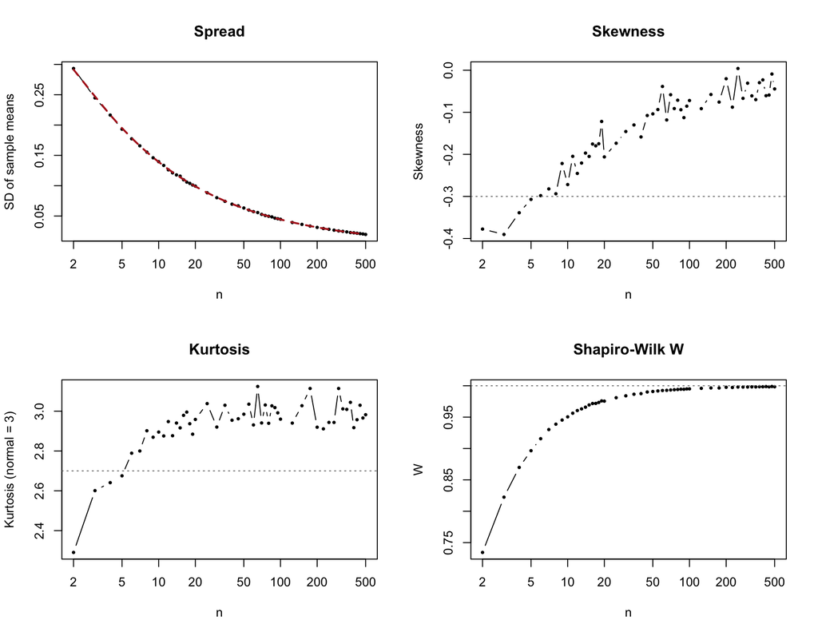

Red dashed (spread) = sum-of-variances SE. No single theory line for skewness or kurtosis here. Gray dotted = my cutoff.

```r
plot_trends(results_exact, cutoff = cutoff)
```

```r
show_rows <- results$n %in% c(2, 4, 5, 6, 7, 8, 10, 20, 30, 50, 100, 500)
knitr::kable(round(results_exact[show_rows, ], 3), row.names = FALSE)
```

| n | mean | sd | theory_se | skewness | kurtosis | shapiro_w | sd_error |
| --- | --- | --- | --- | --- | --- | --- | --- |
| 2 | 0.699 | 0.293 | 0.292 | -0.378 | 2.291 | 0.734 | 0.006 |
| 4 | 0.698 | 0.216 | 0.217 | -0.339 | 2.641 | 0.870 | 0.001 |
| 5 | 0.702 | 0.193 | 0.195 | -0.307 | 2.675 | 0.897 | 0.009 |
| 6 | 0.698 | 0.177 | 0.179 | -0.298 | 2.789 | 0.916 | 0.007 |
| 7 | 0.701 | 0.166 | 0.166 | -0.282 | 2.800 | 0.930 | 0.001 |
| 8 | 0.700 | 0.155 | 0.155 | -0.294 | 2.902 | 0.939 | 0.001 |
| 10 | 0.700 | 0.140 | 0.139 | -0.272 | 2.895 | 0.950 | 0.003 |
| 20 | 0.700 | 0.099 | 0.099 | -0.206 | 2.958 | 0.975 | 0.006 |
| 30 | 0.701 | 0.080 | 0.081 | -0.146 | 2.920 | 0.984 | 0.007 |
| 50 | 0.700 | 0.063 | 0.063 | -0.104 | 2.985 | 0.991 | 0.010 |
| 100 | 0.700 | 0.045 | 0.044 | -0.072 | 2.960 | 0.995 | 0.009 |
| 500 | 0.700 | 0.020 | 0.020 | -0.044 | 2.982 | 0.998 | 0.010 |

```r
c(max_mean_gap = round(max(abs(results$mean - 0.7)), 4))
```

```
max_mean_gap
      0.0018
```

The average shooting percentage is within 0.002 of 0.70 at every n. Skewness starts negative (-0.38 at n = 2), because most shots are better than 50% and the percentage cannot go above 1. It drops under 0.3 in size at n = 6, and from n = 200 on it stays within 0.09 of 0 (it is even slightly positive at n = 250). Kurtosis starts low (2.29 at n = 2) and stays between about 2.87 and 3.12 from n = 8 on. Shapiro W is only 0.734 at n = 2 and still 0.975 at n = 20. Like the die and binomial, the shooting percentage can only take a few values (multiples of 1/n), so lots of results are tied.

## 6 A closer look

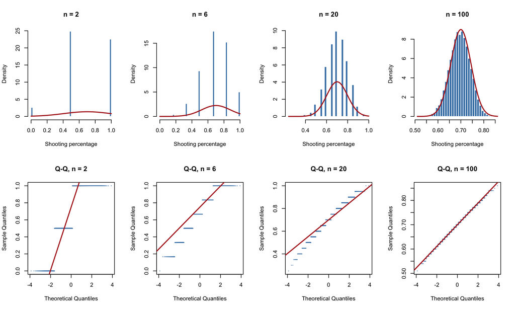

Red curve = normal with the sum-of-variances SE.

```r
chosen_n <- smallest_n(results_exact, cutoff = cutoff)
show_n <- c(2, chosen_n, 20, 100)

old_par <- par(mfrow = c(2, 4))

for (n in show_n) {
  m <- sim$means[[as.character(n)]]
  hist(m, breaks = 40, probability = TRUE, col = "steelblue", border = "white",
       main = paste("n =", n), xlab = "Shooting percentage")
  curve(dnorm(x, mean = 0.7, sd = exact_se(n)), add = TRUE, col = "firebrick", lwd = 2)
}

for (n in show_n) {
  m <- sim$means[[as.character(n)]]
  qqnorm(m, main = paste("Q-Q, n =", n), pch = 16, cex = 0.3, col = "steelblue")
  qqline(m, col = "firebrick", lwd = 2)
}
```

```r
par(old_par)
```

At n = 2 a game can only be 0%, 50% or 100%, so there are just three bars. At n = 6 there are 7 possible values, and about 10% of the simulated games were 6 for 6 (the exact chance is 10.5%). That is the long flat step at 100% in the Q-Q plot, since the percentage cannot go any higher. The bottom of the staircase also sits more than one step under the line. So at n = 6 the numbers pass, but the plot is still a rough staircase. By n = 20, the game length in the handout, the staircase follows the line except for the bottom few steps, and at n = 100 it is right on it. The comb-shaped histograms with bars sticking out above the red curve are the same binning effect as in the die file.

## 7 My decision

```r
# with the usual sigma / sqrt(n)
smallest_n(results, cutoff = cutoff)
```

```
[1] NA
```

```r
# with the sum-of-variances SE
chosen_n
```

```
[1] 6
```

With the usual formula, my rule never passes. Skewness and kurtosis are fine early, but the sd check keeps failing because σ/√n is the wrong SE here. With the SE that adds up each shot’s variance, the smallest n I can defend is **n = 6**. Because a 6-shot game can only land on 7 values, I would call that the lowest n that works rather than a comfortable answer.

Same data, different cutoff (using the sum-of-variances SE):

```r
data.frame(
  cutoff = c(0.5, 0.3, 0.2, 0.1, 0.05),
  smallest_n = sapply(c(0.5, 0.3, 0.2, 0.1, 0.05), function(k) smallest_n(results_exact, cutoff = k))
)
```

```
  cutoff smallest_n
1   0.50          3
2   0.30          6
3   0.20         25
4   0.10        325
5   0.05        475
```

With a 0.5 cutoff n = 3 is enough, and with 0.2 it is 25, so 30 is enough here even under the strict cutoff. As in the other files, I do not read much into the 0.1 and 0.05 rows.

## 8 Changing p versus a constant 70% shooter

```r
smallest_n(constant, cutoff = cutoff)
```

```
[1] 10
```

```r
compare_rows <- c(5, 10, 20, 50)
print(data.frame(
  n = compare_rows,
  changing_p_skew = round(results$skewness[results$n %in% compare_rows], 3),
  constant_p_skew = round(constant$skewness[constant$n %in% compare_rows], 3)
), row.names = FALSE)
```

```
  n changing_p_skew constant_p_skew
  5          -0.307          -0.417
 10          -0.272          -0.296
 20          -0.206          -0.212
 50          -0.104          -0.143
```

The constant 70% shooter needs n = 10, close to the 9 the formula predicted. The changing-p shooter got there faster, and its skewness is smaller in size at every n in the table. My guess at why: the shots near the end, close to 50%, are the most random ones (p(1 - p) is 0.25 at p = 0.5 versus 0.09 at p = 0.9), and they are close to symmetric. So most of the game-to-game noise comes from nearly symmetric shots, while the very lopsided early shots barely add any.

## 9 Does the seed matter?

```r
sim_167 <- run_simulation(
  generator = function(n) rbinom(n, size = 1, prob = shot_probs(n)),
  pop_sd = sqrt(0.7 * 0.3),
  seed = 167
)$results
sim_167$theory_se <- sapply(sim_167$n, exact_se)
sim_167$sd_error <- abs(sim_167$sd - sim_167$theory_se) / sim_167$theory_se
smallest_n(sim_167, cutoff = cutoff)
```

```
[1] 8
```

```r
constant_167 <- run_simulation(
  generator = function(n) rbinom(n, size = 1, prob = 0.7),
  pop_sd = sqrt(0.7 * 0.3),
  seed = 167
)$results
smallest_n(constant_167, cutoff = cutoff)
```

```
[1] 9
```

With seed 167 the changing-p shooter needs n = 8 and the constant shooter needs 9. So it is faster with both seeds, but with seed 167 the gap is only one shot. For the changing-p version I would put the answer around 6 to 8.

## 10 What surprised me

Non-identical shots sound like they should make the CLT slower, but it was actually a little faster than a constant 70% shooter. The part that broke was the SE formula. If I had plugged in σ/√n with p = 0.7 without thinking about it, my rule would have said this never becomes normal, and I would have blamed the shape. The project instructions said not to apply the usual formula automatically, and this is a good example of why.